# SourceMeter 10.0 for C#

# Introduction

FrontEndART SourceMeter for C# is a source code analyzer tool, which can perform deep static analysis of the source code of complex C# systems (https://www.sourcemeter.com).

The source code of a program is usually its only up-to-date documentation. At the same time, the source code is the exquisite bearer of knowledge, business processes and methodology, accumulated over a long period of time. Source code quality decrease, which happens due to many quick fixes and time pressure, results in the increase of development and testing costs, and operational risks. In spite of this, the source code usually receives hostile treatment and is merely considered as a tool.

FrontEndART has developed SourceMeter based on the Columbus technology researched and developed at the [Department of Software Engineering](http://www.sed.inf.u-szeged.hu/softwarequality) of the University of Szeged. SourceMeter provides deep static analysis of source code. Using the results of the analysis, the quality of the analyzed source code can be improved and developed both in the short- and long term in a directed way.

All features of SourceMeter for C# are free, but in the free version the number of metrics is limited to 14.

## Product characteristics

The most important product characteristics of FrontEndART SourceMeter are the following:

- Transparent integration into build processes
- Powerful filter management
- Coding issue detection:
  - Metric threshold violations (MetricHunter module)
  - FxCop coding rule violations
  - SONARQUBE™ platform 8.0 (“SonarQube” in the following) coding rule violations
  - Roslyn Analyzer coding rule violations
- Clone detection (copy-pasted source code fragments) extended with clone tracking and “clone smells”
  - Syntax-based, so-called Type-2 clones
- Metrics calculation at component, file, namespace, class, structure, interface and method levels:
  - Source code metrics
  - Clone metrics
  - Coding rule violation metrics

By continuous static analysis, the software developers can:

- reduce the software erosion rate and this way decrease development costs;
- coding problems can be identified before testing, so the number of test iterations and the testing costs can be reduced;
- the number of errors in delivered software can be reduced, so the operational risks can be decreased, increasing the company’s reputation.

SourceMeter can analyze source code conforming to C# 8. The following can be analyzed: a solution (.sln), a project (.csproj) or a single source file (.cs). In case of a project or a solution, it is recommended to build it with pdb generation enabled before analysing, therefore FxCop can be run on the binaries in parallel. See more on this in the FxCop appendix.

With the help of the filtering mechanism it is possible to specify a certain part of the ASG to be used (or not to be used) during the analysis, hence the results can be made more focused and the usage of memory and CPU can be reduced (e.g. generated source files or test code can be filtered out).

Visit our corporate website at http://www.frontendart.com to find the latest information about SourceMeter and read more about related products and services. Note, that if you are using only the free features of SourceMeter, we do not provide any free support for it. However, FrontEndART offers support services, so please feel free to search for solutions to your problems on our website and contact us with any questions you might have. We welcome feedback about the usability and eventual issues of the tool and further development suggestions at .

## Background

During the static analysis, an Abstract Semantic Graph (ASG) is constructed from the language elements of the source code. This ASG is then processed by the different tools in the package to calculate product metrics, identify copy-pasted code (clones), coding rule violations, etc.

# Installation

## Supported platforms

SourceMeter supports the following x64 platforms:

- Microsoft Windows 7 SP1 or newer
- Microsoft Windows Server 2012 or newer
- GNU/Linux with kernel version 2.6.18 and GNU C library 2.11 or newer

## Requirements

The following software packages are required to be installed:

- [.NET Core SDK 3.1](https://dotnet.microsoft.com/download/visual-studio-sdks)
- [Microsoft Visual C++ 2017 Redistributable Package](https://aka.ms/vs/15/release/VC_redist.x64.exe) - on Windows

## Installation package

The SourceMeter installation package can be extracted into any folder and used from that location. It can be executed with the command line program SourceMeterCsharp.

The SourceMeter for C# package contains the following directories and files:

Windows:

| SourceMeter\Csharp\ |  |  |
| --- | --- | --- |
|  | Demo | # Example project directory |
|  | WindowsTools | # ASG checker and exporter tools directory |
|  | SourceMeterCsharp.exe | # Program file to execute the analysis |
|  | UsersGuide.html | # User’s guide |

Linux:

| SourceMeter/Csharp/ |  |  |
| --- | --- | --- |
|  | Demo | # Example project directory |
|  | LinuxTools | # ASG checker and exporter tools directory |
|  | SourceMeterCsharp | # Program file to execute the analysis |
|  | UsersGuide.html | # User’s guide |

## License key

The free version of SourceMeter does not require any license key file.

In order to use the commercial version of SourceMeter with all features, it is necessary to obtain the license key file named LICENSE.DAT.

Windows:

The license key file must be copied into the root directory of the extracted package (next to the readme.txt file) or into the %APPDATA%\FrontEndART\SourceMeter\ directory of the user.

Linux:

The license key file must be copied into the root directory of the extracted package (next to the readme.txt file) or into the $HOME/.FrontEndART/SourceMeter/ directory of the user.

In case of the first option, anyone who has permissions to access and execute the binaries of the package will be able to use SourceMeter, while in case of the second option only those users will be able to use SourceMeter, who have the license key file in the above-mentioned directory. If one would like to renew an expired license key, the already existing license key file must be replaced with the new one in the above-mentioned directories. To use SourceMeter it is also necessary to have read and write permission on the license key file.

# Preconditions

## Solution or Project analysis

The software system shall be compilable with C# 8 and the build process with MSBuild 16.

In order to use SourceMeter for C# it is necessary to meet all the requirements of your project’s build process. Before starting the analysis, it is recommended to build your solution using Visual Studio or the .NET Core SDK commandline tools. If it failed, check that the following are installed:

- Git submodules
- NuGet packages or other external dependencies
- The required MsBuild workloads, Targeting Packs, SDKs

If it completed successfully, you can proceed with SourceMeter.

FxCop operates on binaries, therefore you **must** build the project before running SourceMeter in order to have FxCop results.

If your projects reference Roslyn Analyzers, their results will be imported into SourceMeter’s results by default.

### Version constraints

- C# language up to 8
- Solution and project file formats up to Visual Studio 2019 (16.0)
- The targeted .NET Framework does not matter, but the corresponding targeting pack and/or SDK must be installed. The project can target other runtimes like .NET Core and .NET Standard as well.

## Single file analysis

It is possible to analyze a single source file (.cs), which can be provided instead of a solution or project. The file will be assumed to target `netcoreapp3.1`. Analyzing multiple source files without a project is not supported.

# Command line parameters

SourceMeter can be executed with the following parameters:

**-help**

It displays the detailed help and exits.

**-resultsDir**

Relative or absolute path name of the directory where the results of the analysis will be stored. The directory will be created automatically if it does not exist.

**-projectName**

The name of the analyzed software system. The name specified here will be used for storing the results.

**-input**

The solution (.sln), project (.csproj) or C# source (.cs) file to analyse.

**-externalHardFilter**

Filter file specified with relative or absolute path, to filter out certain files from the analysis based on their path names. Filtered files will not appear in the results. The filter file is a simple text file containing lines starting with ‘+’ or ‘-’ characters followed by a regular expression[^1]. Tip: you can use the and anchors to make a substring literal, reducing the need of escaping backslashes. During the analysis, each input file will be checked for these expressions. If the first character of the last matching expression is ‘-’, then the given file will be excluded from the analysis. If the first character of the last matching expression is ‘+’, or there is no matching expression, then the file will be analyzed. A line starting with a different character than ‘-’ or ‘+’ will be ignored. Checking is case-insensitive. Example filter file content:

```
# Filter out all source files starting with "test":
-test[^\.]*.cs
# But test576.cs is needed:
+test576.cs
# Furthermore, files beginning with "test1742" are also needed:
+test1742[^\.]*.cs
# Finally, test1742_b.cs is not needed:
-test1742_b.cs
```

**-externalSoftFilter**

Filter file specified with relative or absolute path to filter out source code elements (e.g. classes, methods) which are not important for some reason, but could not be filtered out via the externalHardFilter parameter. Source files containing these elements will be analyzed, but the matching results will not be calculated. The filter file is a simple text file containing lines starting with ‘+’ or ‘-’ characters followed by a regular expression. Tip: you can use the and anchors to make a substring literal, reducing the need of escaping backslashes. Checking is case-insensitive. After the analysis, those source elements whose absolute path of their source position last matches an expression starting with ‘-’ will not be considered in the results. If the first character of the last matching expression is ‘+’, or there is no matching expression, then the source element will be considered as part of the software system. Example filter file content:

[output not shown]

Directory structure marked with the results of filtering:

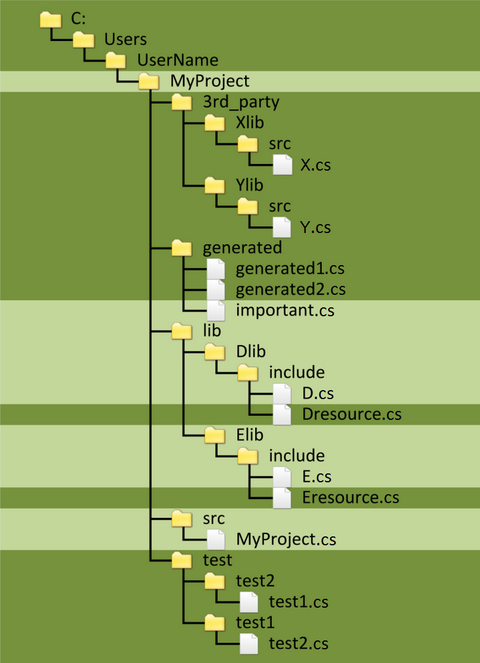

Source code elements in the files marked with darker background will not be considered when creating the results of the analysis.

**-runMetricHunter**

This parameter turns on or off the MetricHunter module. With this feature, SourceMeter lists metric threshold violations. Its value can be “true” (turn this feature on) or “false” (turn this feature off). The default value is “true”.

**-runDCF**

This parameter turns on or off the DuplicatedCodeFinder module. With this feature, SourceMeter identifies copy-pasted code fragments. Its value can be “true” (turn this feature on) or “false” (turn this feature off). The default value is “true”.

**-runMET**

This parameter turns on or off the Metric module. With this feature, SourceMeter computes source code metrics. Its value can be “true” (turn this feature on) or “false” (turn this feature off). The default value is “true”.

**-runRoslynAnalyzers**

This parameter turns on or off the importing of Roslyn Analyzers’ results. With this feature, SourceMeter will run the projects’ referenced analyzers and incorporate their results into the output. Its value can be “true” (turn this feature on) or “false” (turn this feature off). The default value is “true”.

**-profileXML**

Global configuration file for SourceMeter. Its *tool-options* tag can be used to override the default metric thresholds for the MetricHunter tool or define custom metric formulas for the UserDefinedMetrics tool. Furthermore, its *rule-options* tag can enable/disable or modify the priorities of multiple rules. An example profile xml file is shown below:

```xml
<sourcemeter-profile>
  <tool-options>
    <tool name = "MetricHunter" enabled = "true">
      <metric-thresholds>
        <threshold metric-id="LOC" relation="gt" value="100" entity="Method" />
        <threshold metric-id="LLOC" relation="gt" value="none" entity="Method" />
        <threshold metric-id="NUMPAR" relation="gt" value="43" entity="Method" />
        <threshold metric-id="TLOC" relation="gt" value="-32" entity="Method" />
      </metric-thresholds>
    </tool>
  </tool-options>

  <rule-options>
    <rule id="AEC" name="Avoid excessive complexity" priority="Minor" enabled="false"/>
    <rule id="DNREIEC" name="Do not raise exceptions in exception clauses" priority="Major" enabled="true"/>
  </rule-options>
</sourcemeter-profile>
```

**-runUDM**

This parameter turns on or off the UserDefinedMetrics module. With this feature, SourceMeter computes custom source code metrics based on other, previously computed metrics. Its value can be “true” (turn this feature on) or “false” (turn this feature off). The default value is dependent on the presence of custom metric definitions in the profile xml.

**-cloneGenealogy**

This parameter turns on or off the tracking of code clones (copy-pasted source code fragments) through the consecutive revisions of the software system. It is required that during the analysis of the different revisions, the values set to projectName and resultsDir remain the same, so SourceMeter will handle them as different revisions of the same system. Its value can be “true” (turn this feature on) or “false” (turn this feature off). The default value is “false”.

**-cloneMinLines**

This parameter sets the minimum required size of each duplication in lines of code. The default value is 10.

**-csvSeparator**

This parameter sets the separator character in the CSV outputs. The default value is the comma (“,”). The character set here must be placed in quotation marks (e.g. -csvSeparator=“;”). Tabulator character can be set by the special “\t” value.

**-csvDecimalMark**

This parameter sets the decimal mark character in the CSV outputs. The default is locale dependent. The character set here must be placed in quotation marks (e.g. -csvDecimalMark=“,”)

**-sarifseverity**

This parameter sets the severity levels to be saved in the SARIF output. (1 - Info, 2 - Minor, 3 - Major, 4 - Critical, 5 - Blocker, c/C - CloneClass). The value should not be placed in quotation marks (e.g. -sarifseverity=2345c). The default value is 2345c.

**-maximumThreads**

This parameter sets the maximum number of parallel tasks the controller can start. The default value is the number of available CPU cores on the current system.

**-currentDate**

The name of the directory with date inside the result directory of the project. If it is not set, then the current date is used.

**-cleanResults**

Cleans all but the last n number of timestamped result directory of the current project.

**-runFxCop**

This parameter turns on or off the FxCop coding rule violation checking. With this feature, SourceMeter lists coding rule violations detected by FxCop. Its value can be “true” (turn this feature on) or “false” (turn this feature off). The default value is “true”. FxCop is only able to run if there was a successful build of the given project with pdb files generated.

**-FxCopPath**

Specifies the the directory which contains the FxCop binaries. If not provided, the program will search through the installed Visual Studio directories and use the latest one if found.

**-configuration**

The name of the project configuration.

**-platform**

The name of the target platform.

**-runSQ**

Import issues from SonarQube server.

**-SQHost**

The URL address of the SonarQube server.

**-SQPort**

The port of the SonarQube server.

**-SQProjectKey**

The key of the project in the SonarQube server.

**-SQProjectPrefix**

Prefix path of the project’s base directory (the path of the sonar-project.properties file).

**-SQUserName**

The user name for the SonarQube server.

**-SQPassword**

The password for the SonarQube server.

**-SQLanguageKey**

The key of the language in SonarQube.

**-runLIM2Patterns**

This parameter can be used to enable or disable the LIM2Patterns module during analysis (default = on).

**-pattern**

The pattern file or pattern directory for LIM2Patterns. By default it searches for the predefined Anti Patterns found in Tools/Patterns/AntiPatterns.

# Usage

Execute the following command to analyse the source code of a software system:

```
SourceMeterCsharp.exe -input="c:\My Project\MyProject.sln" -projectName=MyProject -resultsDir=Results
  -configuration=Debug -platform=AnyCPU
```

# Result files

If any problems occur in the execution of the tools of the SourceMeter package during the code analysis, SourceMeter returns with error code 1. The error code of the given tool appears on the screen (detailed information on the bug can be found in the log directory), and the analysis is stopped, but the result files created until the failure are not deleted.

An error-free execution of SourceMeter produces the following files:

- Files containing the results of the static analysis in the results directory (set by the resultsDir parameter):
  - $(projectName)\csharp\$(DATE)\$(projectName)-*.csv

    CSV (comma separated values) files containing different metrics: Component, File, Namespace, Class, Interface, Structure, Enum, Method, and Attribute level source code metrics, rule violation counts, and clone-related metrics at CloneClass and CloneInstance level.
  - $(projectName)\csharp\$(DATE)\$(projectName)-clones.txt

    List of the code clones (copy-pasted source code fragments) in the system.
  - $(projectName)\csharp\$(DATE)\$(projectName)-MetricHunter.txt

    List of the MetricHunter metric value violations in the system.
  - $(projectName)\csharp\$(DATE)\$(projectName)-FxCop.txt

    List of the FxCop coding rule violations in the system.
  - $(projectName)\csharp\$(DATE)\$(projectName).graph

    Binary representation of the result graph containing all the metrics, code clones and coding rule violations.
  - $(projectName)\csharp\$(DATE)\$(projectName).xml

    XML representation of the result graph containing all the metrics, code clones and coding rule violations.
  - $(projectName)\csharp\$(projectName).gsi

    Binary data file containing information for tracking the code clones through the consecutive revisions of the analysed software system.
  - $(projectName)\csharp\$(DATE)\$(projectName).sarif

    SARIF representation of the rule violations.
  - $(projectName)\csharp\$(DATE)\$(projectName)-summary.graph

    Binary representation of the summary result graph containing only the System component node.
  - $(projectName)\csharp\$(DATE)\$(projectName)-summary.xml

    XML representation of the summary result graph containing only the System component node.
  - $(projectName)\csharp\$(DATE)\$(projectName)-summary.json

    JSON representation of the summary result graph containing only the System component node.
- Other files and directories created in the results directory:
  - $(projectName)\csharp\$(DATE)\sourcemeter

    Directory, which contains configuration, binary, ASG, log, and temporary files created during the source code analysis.
  - $(projectName)\csharp\$(DATE)\sourcemeter\asg

    Directory, which contains the linked ASG and LIM files, the corresponding filter files, and the GSI file.
  - $(projectName)\csharp\$(DATE)\sourcemeter\graph

    Directory, which contains backup copies of the graph files.
  - $(projectName)\csharp\$(DATE)\sourcemeter\log

    Directory, which contains the log files created during the code analysis.
  - $(projectName)\csharp\$(DATE)\sourcemeter\temp

    Directory, which contains the temporary files created during the code analysis.

It is important to note that “standard parts” are not taken into consideration while creating the results. This means that e.g. when a class does not have an explicit superclass, its number of parents (and ancestors) will be 0 (zero) despite the fact that every C# class inherits implicitly from object, which would suggest that the number will be 1. Similarly, other metrics and results also disregard “standard parts”.

# Coding rule violation suppression

SourceMeter for C# currently does not have its own coding rule violation checker. We use Microsoft’s FxCop and incorporate its results into ours. You can find out more on the [MSDN site of FxCop](https://msdn.microsoft.com/en-us/library/bb429476%28v=vs.80%29.aspx).

The warnings of MetricHunter cannot be suppressed at the moment.

# Demo

The Demo directory of the installation package contains an example project and scripts to run an analysis. The log4net open source C# program is included as the example project, which can also be downloaded from the following URL:

http://archive.apache.org/dist/logging/log4net/source/log4net-2.0.10-src.zip

To perform the source code analysis of the demo project, execute the `analyze.bat` or `analyze.sh` file depending on your platform. The script will try to build log4net with the .NET Core SDK, then run the analysis on it.

Contents of the Demo directory:

| demo\ |  |  |
| --- | --- | --- |
|  | log4net-2.0.10 | # source code of log4net version 2.0.10 |
|  | hardfilter | # example hardfilter file, see above |
|  | softfilter | # example softfilter file, see above |
|  | analyze.bat | # batch file to run the demo analysis |

# Error messages

- Message: There is no valid license!

  Solution: Install a valid license key file (see Installation section).
- Message: Please set the resultsDir parameter. Under this directory a new directory with the name of the analyzed project will be created, if it does not exist yet. All results will be stored there under separate directories with their names containing the date and time.

  Solution: The resultsDir parameter must be set.
- Message: Please set the projectName parameter to the name of the analyzed software system.

  Solution: The projectName parameter must be set.
- Message: error NETSDK1064: Package Some.Dependency.Package, version 1.0.0 was not found. It might have been deleted since NuGet restore. Otherwise, NuGet restore might have only partially completed, which might have been due to maximum path length restrictions.

  Soltuion: Restore NuGet packages before starting the analysis.

# Known bugs and deficiencies

Known bugs and deficiencies of SourceMeter for C#.

- SourceMeter places the results into the directory specified by the projectName parameter. If special characters (like ‘<’, ‘>’, etc.) are used in the parameter, the analysis will probably fail.
- FxCop may not run if placed in a directory containing special characters. To be safe, run SourceMeter and FxCop from a directory containing english letters, numbers, hyphen and underscore only.
- Due to [limitations of the underlying Roslyn API](https://github.com/dotnet/roslyn/issues/6535#issuecomment-273821725), SourceMeter for C# ignores build configuration and platform mappings specified in solution files’ ProjectConfigurationPlatforms section. The specified configuration and platform are used for every project. This can cause invalid preprocessor directives and thus code parts being included or omitted which would not be in a normal build. Also most of the time the OutputPath of a project is dependent on the configuration and the platform, resulting in that FxCop will not be run, because SourceMeter can not determine the correct path. To mitigate this problem, use the same configuration and platform values in every project in a solution.

# FAQ

Frequently Asked Questions regarding SourceMeter.

- Problem: On Windows platforms, in case of deep directory hierarchies, it may happen that the full paths of some files exceed 259 characters. In this case some SourceMeter tools may have problems with opening these files; they will terminate and write appropriate messages in the logs.

  Solution: Move the files to be analyzed to a directory closer to the file system root, or use the ‘subst’ shell command.

# Appendices

## Reference of source code metrics

Source code metrics are used to quantify different source code characteristics. FrontEndART SourceMeter computes source code metrics for the following source code element kinds: components (e.g. C# assemblies), source files, namespaces, types (including classes, interfaces, enums and structures) and methods.

The calculated metrics are grouped into 6 categories, which are the following:

- **Cohesion metrics:** measure to what extent the source code elements are coherent in the system.
- **Complexity metrics:** measure the complexity of source code elements (typically algorithms).
- **Coupling metrics:** measure the amount of interdependencies of source code elements.
- **Documentation metrics:** measure the amount of comments and documentation of source code elements in the system.
- **Inheritance metrics:** measure the different aspects of the inheritance hierarchy of the system.
- **Size metrics:** measure the basic properties of the analyzed system in terms of different cardinalities (e.g. number of code lines, number of classes or methods).

In the case of the documentation metrics all the comments found immediately before a source code element are considered as its documentation, while the comments contained inside the source code element are considered as its comments.

The following table summarizes the metrics, their abbreviations and their correspondence to different source code element kinds:

| Category | Metric name | Abbreviation | Class | Component | Delegate | Enum | File | Interface | Method | Namespace | Structure |
| --- | --- | --- | --- | --- | --- | --- | --- | --- | --- | --- | --- |
| Cohesion metrics | Lack of Cohesion in Methods 5 | LCOM5 | X |  |  |  |  |  |  |  | X |
| Complexity metrics | McCabe’s Cyclomatic Complexity | McCC |  |  |  |  | X |  | X |  |  |
|  | Nesting Level | NL | X |  |  |  |  |  | X |  | X |
|  | Nesting Level Else-If | NLE | X |  |  |  |  |  | X |  | X |
|  | Weighted Methods per Class | WMC | X |  |  |  |  |  |  |  | X |
| Coupling metrics | Coupling Between Object classes | CBO | X |  |  |  |  | X |  |  | X |
|  | Coupling Between Object classes Inverse | CBOI | X |  |  |  |  | X |  |  | X |
|  | Number of Incoming Invocations | NII | X |  |  |  |  | X | X |  | X |
|  | Number of Outgoing Invocations | NOI | X |  |  |  |  |  | X |  | X |
|  | Response set For Class | RFC | X |  |  |  |  |  |  |  | X |
| Documentation metrics | API Documentation | AD | X |  |  | X |  | X |  | X | X |
|  | Comment Density | CD | X |  | X |  |  |  | X | X | X |
|  | Comment Lines of Code | CLOC | X |  | X |  | X | X | X | X | X |
|  | Documentation Lines of Code | DLOC | X |  | X | X |  | X | X |  | X |
|  | Public Documented API | PDA | X |  |  |  | X | X |  | X | X |
|  | Public Undocumented API | PUA | X |  |  |  | X | X |  | X | X |
|  | Total API Documentation | TAD |  | X |  |  |  |  |  | X |  |
|  | Total Comment Density | TCD | X | X | X |  |  |  | X | X | X |
|  | Total Comment Lines of Code | TCLOC | X | X | X |  |  | X | X | X | X |
|  | Total Public Documented API | TPDA |  | X |  |  |  |  |  | X |  |
|  | Total Public Undocumented API | TPUA |  | X |  |  |  |  |  | X |  |
| Inheritance metrics | Depth of Inheritance Tree | DIT | X |  |  |  |  | X |  |  | X |
|  | Number of Ancestors | NOA | X |  |  |  |  | X |  |  | X |
|  | Number of Children | NOC | X |  |  |  |  | X |  |  | X |
|  | Number of Descendants | NOD | X |  |  |  |  | X |  |  | X |
|  | Number of Parents | NOP | X |  |  |  |  | X |  |  | X |
| Size metrics | Lines of Code | LOC | X |  | X | X | X | X | X | X | X |
|  | Logical Lines of Code | LLOC | X |  | X | X | X | X | X | X | X |
|  | Number of Attributes | NA | X |  |  | X |  | X |  | X | X |
|  | Number of Classes | NCL |  |  |  |  |  |  |  | X |  |
|  | Number of Enums | NEN |  |  |  |  |  |  |  | X |  |
|  | Number of Getters | NG | X |  |  |  |  | X |  | X | X |
|  | Number of Interfaces | NIN |  |  |  |  |  |  |  | X |  |
|  | Number of Local Attributes | NLA | X |  |  |  |  | X |  |  | X |
|  | Number of Local Getters | NLG | X |  |  |  |  | X |  |  | X |
|  | Number of Local Methods | NLM | X |  |  |  |  | X |  |  | X |
|  | Number of Local Public Attributes | NLPA | X |  |  |  |  | X |  |  | X |
|  | Number of Local Public Methods | NLPM | X |  |  |  |  | X |  |  | X |
|  | Number of Local Setters | NLS | X |  |  |  |  | X |  |  | X |
|  | Number of Methods | NM | X |  |  |  |  | X |  | X | X |
|  | Number of Packages | NPKG |  |  |  |  |  |  |  | X |  |
|  | Number of Parameters | NUMPAR |  |  |  |  |  |  | X |  |  |
|  | Number of Public Attributes | NPA | X |  |  |  |  | X |  | X | X |
|  | Number of Public Methods | NPM | X |  |  |  |  | X |  | X | X |
|  | Number of Setters | NS | X |  |  |  |  | X |  | X | X |
|  | Number of Statements | NOS | X |  |  |  |  |  | X |  | X |
|  | Number of Structures | NST |  |  |  |  |  |  |  | X |  |
|  | Total Lines of Code | TLOC | X | X | X | X |  | X | X | X | X |
|  | Total Logical Lines of Code | TLLOC | X | X | X | X |  | X | X | X | X |
|  | Total Number of Attributes | TNA | X | X |  |  |  | X |  | X | X |
|  | Total Number of Classes | TNCL |  | X |  |  |  |  |  | X |  |
|  | Total Number of Directories | TNDI |  | X |  |  |  |  |  | X |  |
|  | Total Number of Enums | TNEN |  | X |  |  |  |  |  | X |  |
|  | Total Number of Files | TNFI |  | X |  |  |  |  |  | X |  |
|  | Total Number of Getters | TNG | X | X |  |  |  | X |  | X | X |
|  | Total Number of Interfaces | TNIN |  | X |  |  |  |  |  | X |  |
|  | Total Number of Local Attributes | TNLA | X | X |  |  |  | X |  |  | X |
|  | Total Number of Local Getters | TNLG | X | X |  |  |  | X |  |  | X |
|  | Total Number of Local Methods | TNLM | X | X |  |  |  | X |  |  | X |
|  | Total Number of Local Public Attributes | TNLPA | X | X |  |  |  | X |  |  | X |
|  | Total Number of Local Public Methods | TNLPM | X | X |  |  |  | X |  |  | X |
|  | Total Number of Local Setters | TNLS | X | X |  |  |  | X |  |  | X |
|  | Total Number of Methods | TNM | X | X |  |  |  | X |  | X | X |
|  | Total Number of Packages | TNPKG |  | X |  |  |  |  |  | X |  |
|  | Total Number of Public Attributes | TNPA | X | X |  |  |  | X |  | X | X |
|  | Total Number of Public Classes | TNPCL |  | X |  |  |  |  |  | X |  |
|  | Total Number of Public Enums | TNPEN |  | X |  |  |  |  |  | X |  |
|  | Total Number of Public Interfaces | TNPIN |  | X |  |  |  |  |  | X |  |
|  | Total Number of Public Methods | TNPM | X | X |  |  |  | X |  | X | X |
|  | Total Number of Public Structures | TNPST |  | X |  |  |  |  |  | X |  |
|  | Total Number of Setters | TNS | X | X |  |  |  | X |  | X | X |
|  | Total Number of Statements | TNOS | X | X |  |  |  |  | X | X | X |
|  | Total Number of Structures | TNST |  | X |  |  |  |  |  | X |  |

### Cohesion metrics

#### Lack of Cohesion in Methods 5 (LCOM5)

**Class, Structure:** number of functionalities of the class. One of the basic principles of object-oriented programming is encapsulation, meaning that attributes belonging together and the operations that use them should be organized into one class, and one class shall implement only one functionality, i.e. its attributes and methods should be coherent. This metric measures the lack of cohesion and computes into how many coherent classes the class could be split. It is calculated by taking a non-directed graph, where the nodes are the implemented local methods of the class and there is an edge between the two nodes if and only if a common (local or inherited) attribute or abstract method is used or a method invokes another. The value of the metric is the number of connected components in the graph except the ones that contain only constructors, destructors, getters or setters – as they are integral parts of the class.

### Complexity metrics

#### McCabe’s Cyclomatic Complexity (McCC)

**Method:** complexity of the method expressed as the number of independent control flow paths in it. It represents a lower bound for the number of possible execution paths in the source code and at the same time it is an upper bound for the minimum number of test cases needed for achieving full branch test coverage. The value of the metric is initially 1 which increases by 1 for each occurence of the following instructions: if, for, foreach, while, do-while, case label (label that belongs to a switch instruction), catch (handler that belongs to a try block), conditional statement (?:) and conditional access operators (?. and ?[]). Moreover, logical and (&&), logical or (||) and null coalescing (??) expressions also add to the final value because their short-circuit evalutaion can cause branching depending on the first operand. The following language elements do not increase the value: else, try, switch, default label (default label that belongs to a switch instruction), finally.

#### Nesting Level (NL)

**Method:** complexity of the method expressed as the depth of the maximum embeddedness of its conditional, iteration and exception handling block scopes. The following instructions are taken into account: if, else-if, else, for, foreach, while, do-while, switch, try, catch, finally, lock, checked, unchecked, fixed, using statement, conditional statement (?:) and block statements that are directly inside another block statement. The following instructions do not increase the value by themselves; however, if additional embeddednesses can be found in their blocks, they are considered: case and default label.

**Class, Structure:** complexity of the class expressed as the depth of the maximum embeddedness of its conditional, iteration and exception handling block scopes. It is calculated as the maximum nesting level (NL) of its local methods.

#### Nesting Level Else-If (NLE)

**Method:** complexity of the method expressed as the depth of the maximum embeddedness of its conditional, iteration and exception handling block scopes, where in the if-else-if construct only the first if instruction is considered. The following instructions are taken into account: if, for, foreach, while, do-while, switch, try, catch, finally, lock, checked, unchecked, fixed, using statement, conditional statement (?:) and block statements that are directly inside another block statement. The following instructions do not increase the value by themselves; however, if additional embeddednesses can be found in their blocks, they are considered: else, else-if (i.e. in the if-else-if construct the use of else-if does not increase the value of the metric), case and default label.

**Class, Structure:** complexity of the class expressed as the depth of the maximum embeddedness of its conditional, iteration and exception handling block scopes, where in the if-else-if construct only the first if instruction is considered. It is calculated as the maximum nesting level (NLE) of its local methods.

#### Weighted Methods per Class (WMC)

**Class, Structure:** complexity of the class expressed as the number of independent control flow paths in it. It is calculated as the sum of the McCabe’s Cyclomatic Complexity (McCC) values of its local methods.

### Coupling metrics

#### Coupling Between Object classes (CBO)

**Class, Structure:** number of directly used other classes (e.g. by inheritance, function call, type reference, attribute reference). Classes using many other classes highly depend on their environment, so it is difficult to test or reuse them; furthermore, they are very sensitive to the changes in the system.

#### Coupling Between Object classes Inverse (CBOI)

**Class, Structure:** number of other classes, which directly use the class. Classes which are used by many other classes have a high impact on the behavior of the system, and should be modified very carefully and tested intensively.

#### Number of Incoming Invocations (NII)

**Method:** number of other methods and attribute initializations which directly call the method. If the method is invoked several times from the same method or attribute initialization, it is counted only once.

**Class, Structure:** number of other methods and attribute initializations which directly call the local methods of the class. If a method is invoked several times from the same method or attribute initialization, it is counted only once.

#### Number of Outgoing Invocations (NOI)

**Method:** number of directly called methods. If a method is invoked several times, it is counted only once.

**Class, Structure:** number of directly called methods of other classes, including method invocations from attribute initializations. If a method is invoked several times, it is counted only once.

#### Response set For Class (RFC)

**Class, Structure:** number of local (i.e. not inherited) methods in the class (NLM) plus the number of directly invoked other methods by its methods or attribute initializations (NOI).

### Documentation metrics

#### API Documentation (AD)

**Class, Structure:** ratio of the number of documented public methods in the class +1 if the class itself is documented to the number of all public methods in the class + 1 (the class itself); however, the nested and anonymous classes are not included.

**Namespace:** ratio of the number of documented public classes and methods in the namespace to the number of all of its public classes and methods; however, the classes and methods of its subnamespaces are not included.

#### Comment Density (CD)

**Method:** ratio of the comment lines of the method (CLOC) to the sum of its comment (CLOC) and logical lines of code (LLOC).

**Class, Structure:** ratio of the comment lines of the class (CLOC) to the sum of its comment (CLOC) and logical lines of code (LLOC).

**Namespace:** ratio of the comment lines of the namespace (CLOC) to the sum of its comment (CLOC) and logical lines of code (LLOC).

#### Comment Lines of Code (CLOC)

**Method:** number of comment and documentation code lines of the method; however, its anonymous classes are not included.

**Class, Structure:** number of comment and documentation code lines of the class, including its local methods and attributes; however, its nested and anonymous classes are not included.

**Namespace:** number of comment and documentation code lines of the namespace; however, its subnamespaces are not included.

#### Documentation Lines of Code (DLOC)

**Method:** number of documentation code lines of the method.

**Class, Structure:** number of documentation code lines of the class, including its local methods and attributes; however, its nested and anonymous classes are not included.

#### Public Documented API (PDA)

**Class, Structure:** the number of the documented public methods of the class (+1 if the class itself is documented). When calculating the metrics the nested, anonymous or local classes found in the class and their methods are not calculated.

**Namespace:** the number of the documented public classes and public documented methods found in the namespace. When calculating the metric, classes and methods found in the subnamespaces of the namespace are not taken into account.

#### Public Undocumented API (PUA)

**Class, Structure:** the number of the undocumented public methods of the class (+1 if the class itself is undocumented). When calculating the metrics the nested, anonymous or local classes to be found in the class and their methods are not calculated.

**Namespace:** the number of the undocumented public classes and undocumented public methods to be found in the namespace. When calculating the metric, classes and methods to be found in the subnamespaces of the namespace are not taken into account.

#### Total API Documentation (TAD)

**Namespace:** ratio of the number of documented public classes and methods in the namespace to the number of all of its public classes and methods, including its subnamespaces.

**Component:** ratio of the number of documented public classes and methods in the component to the number of all of its public classes and methods, including its subcomponents.

#### Total Comment Density (TCD)

**Method:** ratio of the total comment lines of the method (TCLOC) to the sum of its total comment (TCLOC) and total logical lines of code (TLLOC).

**Class, Structure:** ratio of the total comment lines of the class (TCLOC) to the sum of its total comment (TCLOC) and total logical lines of code (TLLOC).

**Namespace:** ratio of the total comment lines of the namespace (TCLOC) to the sum of its total comment (TCLOC) and total logical lines of code (TLLOC).

**Component:** ratio of the total comment lines of the component (TCLOC) to the sum of its total comment (TCLOC) and total logical lines of code (TLLOC).

#### Total Comment Lines of Code (TCLOC)

**Method:** number of comment and documentation code lines of the method, including its anonymous classes.

**Class, Structure:** number of comment and documentation code lines of the class, including its local methods and attributes, as well as its nested and anonymous classes.

**Namespace:** number of comment and documentation code lines of the namespace, including its subnamespaces.

**Component:** number of comment and documentation code lines of the component, including its subcomponents.

#### Total Public Documented API (TPDA)

**Namespace:** the number of the public documented classes and their public documented methods found in the namespace. When calculating the metric, classes and methods found in subnamespaces of the namespace are also taken into account.

**Component:** the number of public documented classes and public documented methods found in the component, where in calculating the metric, classes and methods to be found in subcomponents of the component are also taken into account.

#### Total Public Undocumented API (TPUA)

**Namespace:** the number of the public undocumented classes and their public undocumented methods found in the namespace. When calculating the metric, classes and methods found in subnamespaces of the namespace are also taken into account.

**Component:** the number of public undocumented classes and public undocumented methods found in the component, where in calculating the metric, classes and methods to be found in subcomponents of the component are also taken into account.

### Inheritance metrics

#### Depth of Inheritance Tree (DIT)

**Class, Structure:** length of the path that leads from the class to its farthest ancestor in the inheritance tree.

#### Number of Ancestors (NOA)

**Class, Structure:** number of classes and interfaces from which the class is directly or indirectly inherited.

#### Number of Children (NOC)

**Class, Structure:** number of classes and interfaces which are directly derived from the class.

#### Number of Descendants (NOD)

**Class, Structure:** number of classes and interfaces which are directly or indirectly derived from the class.

#### Number of Parents (NOP)

**Class, Structure:** number of classes and interfaces from which the class is directly inherited.

### Size metrics

#### Lines of Code (LOC)

**Method:** number of code lines of the method, including empty and comment lines; however, its anonymous classes are not included.

**Class, Structure:** number of code lines of the class, including empty and comment lines, as well as its local methods; however, its nested and anonymous classes are not included.

**Namespace:** number of code lines of the namespace, including empty and comment lines; however, its subnamespaces are not included.

#### Logical Lines of Code (LLOC)

**Method:** number of non-empty and non-comment code lines of the method; however, its anonymous classes are not included.

**Class, Structure:** number of non-empty and non-comment code lines of the class, including the non-empty and non-comment lines of its local methods; however, its nested and anonymous classes are not included.

**Namespace:** number of non-empty and non-comment code lines of the namespace; however, its subnamespaces are not included.

**File:** number of non-empty and non-comment code lines of the file.

#### Number of Attributes (NA)

**Class, Structure:** number of attributes in the class, including the inherited ones and generated ones backing auto properties; however, the attributes of its nested and anonymous classes are not included.

**Namespace:** number of attributes in the namespace; however, attributes of its subnamespaces are not included.

#### Number of Classes (NCL)

**Namespace:** number of classes in the namespace; however, the classes of its subnamespaces are not included.

#### Number of Enums (NEN)

**Namespace:** number of enums in the namespace; however, the enums of its subnamespaces are not included.

#### Number of Getters (NG)

**Class, Structure:** number of getter methods in the class, including the inherited ones; however, the getter methods of its nested and anonymous classes are not included. Methods that override abstract methods are not counted.

**Namespace:** number of getter methods in the namespace; however, getter methods of its subnamespaces are not included.

#### Number of Interfaces (NIN)

**Namespace:** number of interfaces in the namespace; however, the interfaces of its subnamespaces are not included.

#### Number of Local Attributes (NLA)

**Class, Structure:** number of local (i.e. not inherited) attributes in the class, including generated ones backing auto properties; however, the attributes of nested and anonymous classes are not included.

#### Number of Local Getters (NLG)

**Class, Structure:** number of local (i.e. not inherited) getter methods in the class; however, the getter methods of its nested and anonymous classes are not included. Methods that override abstract methods are not counted.

#### Number of Local Methods (NLM)

**Class, Structure:** number of local (i.e. not inherited) methods in the class; however, the methods of nested and anonymous classes are not included.

#### Number of Local Public Attributes (NLPA)

**Class, Structure:** number of local (i.e. not inherited) public attributes in the class, including generated ones backing public auto properties; however, the attributes of nested and anonymous classes are not included.

#### Number of Local Public Methods (NLPM)

**Class, Structure:** number of local (i.e. not inherited) public methods in the class; however, the methods of nested and anonymous classes are not included.

#### Number of Local Setters (NLS)

**Class, Structure:** number of local (i.e. not inherited) setter methods in the class; however, the setter methods of its nested and anonymous classes are not included. Methods that override abstract methods are not counted.

#### Number of Methods (NM)

**Class, Structure:** number of methods in the class, including the inherited ones; however, the methods of its nested and anonymous classes are not included. Methods that override abstract methods are not counted.

**Namespace:** number of methods in the namespace; however, methods of its subnamespaces are not included.

#### Number of Packages (NPKG)

**Namespace:** number of directly contained subnamespaces of the namespace.

#### Number of Parameters (NUMPAR)

**Method:** number of the parameters of the method. The varargs parameter counts as one.

#### Number of Public Attributes (NPA)

**Class, Structure:** number of public attributes in the class, including the inherited ones and generated ones backing public auto properties; however, the public attributes of its nested and anonymous classes are not included.

**Namespace:** number of public attributes in the namespace; however, the public attributes of its subnamespaces are not included.

#### Number of Public Methods (NPM)

**Class, Structure:** number of public methods in the class, including the inherited ones; however, the public methods of nested and anonymous classes are not included. Methods that override abstract methods are not counted.

**Namespace:** number of public methods in the namespace; however, the public methods of its subnamespaces are not included.

#### Number of Setters (NS)

**Class, Structure:** number of setter methods in the class, including the inherited ones; however, the setter methods of its nested and anonymous classes are not included. Methods that override abstract methods are not counted.

**Namespace:** number of setter methods in the namespace; however, setter methods of its subnamespaces are not included.

#### Number of Statements (NOS)

**Method:** number of statements in the method; however, the statements of its anonymous classes are not included.

**Class, Structure:** number of statements in the class; however, the statements of its nested and anonymous classes are not included.

#### Number of Structures (NST)

**Namespace:** number of structures in the namespace; however, the structures of its subnamespaces are not included.

#### Total Lines of Code (TLOC)

**Method:** number of code lines of the method, including empty and comment lines, as well as its anonymous classes.

**Class, Structure:** number of code lines of the class, including empty and comment lines, as well as its local methods, anonymous and nested classes.

**Namespace:** number of code lines of the namespace, including empty and comment lines, as well as its subnamespaces.

**Component:** number of code lines of the component, including empty and comment lines, as well as its subcomponents.

#### Total Logical Lines of Code (TLLOC)

**Method:** number of non-empty and non-comment code lines of the method, including the non-empty and non-comment lines of its anonymous classes.

**Class, Structure:** number of non-empty and non-comment code lines of the class, including the non-empty and non-comment code lines of its local methods, anonymous and nested classes.

**Namespace:** number of non-empty and non-comment code lines of the namespace, including its subnamespaces.

**Component:** number of non-empty and non-comment code lines of the component, including its subcomponents.

#### Total Number of Attributes (TNA)

**Class, Structure:** number of attributes in the class, including the inherited ones and generated ones backing auto properties, as well as the inherited and local attributes of its nested and anonymous classes.

**Namespace:** number of attributes in the namespace, including the attributes of its subnamespaces.

**Component:** number of attributes in the component, including the attributes of its subcomponents.

#### Total Number of Classes (TNCL)

**Namespace:** number of classes in the namespace, including the classes of its subnamespaces.

**Component:** number of classes in the component, including the classes of its subcomponents.

#### Total Number of Directories (TNDI)

**Namespace:** number of directories that belong to the namespace, including the directories of its subnamespaces.

**Component:** number of directories that belong to the component, including its subcomponents.

#### Total Number of Enums (TNEN)

**Namespace:** number of enums in the namespace, including the enums of its subnamespaces.

**Component:** number of enums in the component, including the enums of its subcomponents.

#### Total Number of Files (TNFI)

**Namespace:** number of files that belong to the namespace, including the files of its subnamespaces.

**Component:** number of files that belong to the component, including its subcomponents.

#### Total Number of Getters (TNG)

**Class, Structure:** number of getter methods in the class, including the inherited ones, as well as the inherited and local getter methods of its nested and anonymous classes.

**Namespace:** number of getter methods in the namespace, including the getter methods of its subnamespaces.

**Component:** number of getter methods in the component, including the getter methods of its subcomponents.

#### Total Number of Interfaces (TNIN)

**Namespace:** number of interfaces in the namespace, including the interfaces of its subnamespaces.

**Component:** number of interfaces in the component, including the interfaces of its subcomponents.

#### Total Number of Local Attributes (TNLA)

**Class, Structure:** number of local (i.e. not inherited) attributes in the class, including the generated ones backing auto properties and also attributes of its nested and anonymous classes.

#### Total Number of Local Getters (TNLG)

**Class, Structure:** number of local (i.e. not inherited) getter methods in the class, including the local getter methods of its nested and anonymous classes.

#### Total Number of Local Methods (TNLM)

**Class, Structure:** number of local (i.e. not inherited) methods in the class, including the local methods of its nested and anonymous classes.

#### Total Number of Local Public Attributes (TNLPA)

**Class, Structure:** number of local (i.e. not inherited) public attributes in the class, including the generated ones backing public auto properties and also local public attributes of its nested and anonymous classes.

#### Total Number of Local Public Methods (TNLPM)

**Class, Structure:** number of local (i.e. not inherited) public methods in the class, including the local methods of its nested and anonymous classes.

#### Total Number of Local Setters (TNLS)

**Class, Structure:** number of local (i.e. not inherited) setter methods in the class, including the local setter methods of its nested and anonymous classes.

#### Total Number of Methods (TNM)

**Class, Structure:** number of methods in the class, including the inherited ones, as well as the inherited and local methods of its nested and anonymous classes. Methods that override abstract methods are not counted.

**Namespace:** number of methods in the namespace, including the methods of its subnamespaces.

**Component:** number of methods in the component, including the methods of its subcomponents.

#### Total Number of Packages (TNPKG)

**Namespace:** number of subnamespaces in the namespace, including all directly or indirectly contained subnamespaces.

**Component:** number of namespaces and subnamespaces that belong to the component, including its subcomponents.

#### Total Number of Public Attributes (TNPA)

**Class, Structure:** number of public attributes in the class, including the inherited ones and the generated ones backing public auto properties as well as the inherited and local public attributes of its nested and anonymous classes.

**Namespace:** number of public attributes in the namespace, including the public attributes of its subnamespaces.

**Component:** number of public attributes in the component, including the public attributes of its subcomponents.

#### Total Number of Public Classes (TNPCL)

**Namespace:** number of public classes in the namespace, including the public classes of its subnamespaces.

**Component:** number of public classes in the component, including the public classes of its subcomponents.

#### Total Number of Public Enums (TNPEN)

**Namespace:** number of public enums in the namespace, including the public enums of its subnamespaces.

**Component:** number of public enums in the component, including the public enums of its subcomponents.

#### Total Number of Public Interfaces (TNPIN)

**Namespace:** number of public interfaces in the namespace, including the public interfaces of its subnamespaces.

**Component:** number of public interfaces in the component, including the public interfaces of its subcomponents.

#### Total Number of Public Methods (TNPM)

**Class, Structure:** number of public methods in the class, including the inherited ones, as well as the inherited and local public methods of its nested and anonymous classes.

**Namespace:** number of public methods in the namespace, including the public methods of its subnamespaces.

**Component:** number of public methods in the component, including the public methods of its subcomponents.

#### Total Number of Public Structures (TNPST)

**Namespace:** number of public structures in the namespace, including the public structures of its subnamespaces.

**Component:** number of public structures in the component, including the public structures of its subcomponents.

#### Total Number of Setters (TNS)

**Class, Structure:** number of setter methods in the class, including the inherited ones, as well as the inherited and local setter methods of its nested and anonymous classes.

**Namespace:** number of setter methods in the namespace, including the setter methods of its subnamespaces.

**Component:** number of setter methods in the component, including the setter methods of its subcomponents.

#### Total Number of Statements (TNOS)

**Method:** number of statements in the method, including the statements of its anonymous classes.

**Class, Structure:** number of statements in the class, including the statements of its nested and anonymous classes.

**Namespace:** number of statements in the namespace, including the statements of its subnamespaces.

**Component:** number of statements in the component, including the statements of its subcomponents.

#### Total Number of Structures (TNST)

**Namespace:** number of structures in the namespace, including the structures of its subnamespaces.

**Component:** number of structures in the component, including the structures of its subcomponents.

## Reference of code duplication metrics

Code cloning (or copy-paste programming) means the copying of an existing piece of source code, pasting it somewhere else, and typically performing smaller modifications on it. Based on the level of similarity between the copied code fragments we can define the following duplication types:

- **Type-1**: the copied code parts are identical code fragments except for variations in whitespace, layout and comments.
- **Type-2**: syntactically identical fragments except for variations in identifier names, literals, type references, whitespace, layout and comments.
- **Type-3**: copied fragments with further modifications such as altered, added, or removed statements, in addition to variations in identifier names, literals, type references, whitespace, layout and comments.
- **Type-4**: the copied code fragments are syntactically different, but they perform the same functionality, i.e. they are semantically the same.

FrontEndART SourceMeter is capable of identifying Type-2 clones, i.e. code fragments that are structurally identical, but may differ in variable names, literals, identifiers, etc.

Two code segments correspond to each other if they are copies of each other. This relation is an equivalence relation and we use the notion of clone classes to the classes of the relation, and the members of the classes will be referred to as clone instances. Owing to the nature of the relation, each clone class must contain at least two clone instances.

Clones are tracked during the source code analysis of consecutive revisions of the analyzed software system. FrontEndART SourceMeter detects suspicious, inconsistently changing code copies, which are called “clone smells”. The smells concerning clone classes are the following:

- **Disappearing Clone Class (DCC):** The clone class existed in the previously analyzed revision but it does not exist anymore.
- **Appearing Clone Class (ACC):** The clone class did not exist in the previously analyzed revision.

The smells concerning clone instances are issued only if the containing clone class does not contain any smell. These are the following:

- **Disappearing Clone Instance (DCI):** The clone instance existed in the previously analyzed revision but it does not exist anymore.
- **Appearing Clone Instance (ACI):** The clone instance did not exist in the previously analyzed revision.
- **Moving Clone Instance (MCI):** The clone instance belonged to a different clone class in the previously analyzed revision than its current class.

The following table summarizes the code duplication metrics, their abbreviations, and their correspondence to different source code element types.

| Metric name | Abbrev. | Clone Instance | Clone Class | Method | Class, Struct | Interface | Enum | Namespace | Comp. |
| --- | --- | --- | --- | --- | --- | --- | --- | --- | --- |
| Clone Age | CA | X | X |  |  |  |  |  |  |
| Clone Classes | CCL |  |  | X | X | X | X | X | X |
| Clone Complexity | CCO | X | X | X | X | X | X | X | X |
| Clone Coverage | CC |  |  | X | X | X | X | X | X |
| Clone Elimination Effort | CEE |  | X |  |  |  |  |  | X |
| Clone Elimination Gain | CEG |  | X |  |  |  |  |  | X |
| Clone Embeddedness | CE | X | X |  |  |  |  |  |  |
| Clone Instances | CI |  | X | X | X | X | X | X | X |
| Clone Line Coverage | CLC |  |  | X | X | X | X | X | X |
| Clone Lines of Code | CLLOC | X | X |  |  |  |  |  |  |
| Clone Logical Line Coverage | CLLC |  |  | X | X | X | X | X | X |
| Clone Risk | CR |  | X |  |  |  |  |  | X |
| Clone Variability | CV | X | X |  |  |  |  |  |  |
| Lines of Duplicated Code | LDC |  |  | X | X | X | X | X | X |
| Logical Lines of Duplicated Code | LLDC |  |  | X | X | X | X | X | X |
| Normalized Clone Radius | NCR |  | X |  |  |  |  |  | X |

### Clone metrics

#### Clone Age (CA)

**Clone class/clone instance:** number of previously analyzed revisions in which the clone class/clone instance was present + 1.

#### Clone Classes (CCL)

**Method/class/structure/interface/namespace:** number of clone classes having at least one clone instance in the source code element.

**Component:** number of clone classes having at least one clone instance in the component.

#### Clone Complexity (CCO)

**Clone instance:** the McCabe complexity of the code fragment corresponding to the clone instance.

**Clone class:** sum of CCO of clone instances in the clone class.

**Method/class/interface/namespace/structure:** sum of CCO of clone instances in the source code element.

**Component:** sum of CCO of clone instances in the component.

#### Clone Coverage (CC)

**Method/interface/enum/class/structure/namespace:** ratio of code covered by code duplications in the source code element to the size of the source code element, expressed in terms of the number of syntactic entities (statements, expressions, etc.).

**Component:** ratio of code covered by code duplications in the component to the size of the component, expressed in terms of the number of syntactic entities (statements, expressions, etc.).

#### Clone Elimination Effort (CEE)

**Clone class:** index of the effort required to eliminate the clone class. It is computed as the product of CI, CE, and NCR.

**Component:** index of the effort required to eliminate all clones from the component. It is computed as the sum of CEE of the clone classes in the component.

#### Clone Elimination Gain (CEG)

**Clone class:** index of the gain resulting from eliminating the clone class. It is computed as the ratio of CR to CEE.

**Component:** index of the gain resulting from eliminating all clones from the component. It is computed as the logistic function of the ratio of CR to CEE.

#### Clone Embeddedness (CE)

**Clone instance:** sum of incoming and outgoing references (function calls, variable references, type references; different references to the same entity are counted only once) in the code fragment corresponding to the clone instance, weighted with the number of directory changes between the referenced code fragments.

**Clone class:** sum of CE of the clone instances of the clone class + 1.

#### Clone Instances (CI)

**Method/class/namespace:** number of clone instances in the source code element.

**Component:** number of clone instances in the component.

**Clone class:** number of clone instances in the clone class.

#### Clone Line Coverage (CLC)

**Method/class/interface/namespace:** ratio of code covered by code duplications in the source code element to the size of the source code element, expressed in terms of lines of code.

**Component:** ratio of code covered by code duplications in the component to the size of the component, expressed in terms of lines of code.

#### Clone Lines of Code (CLLOC)

**Clone instance:** length of the clone instance expressed in terms of lines of code.

**Clone class:** average of CLLOC of clone instances belonging to the clone class.

#### Clone Logical Line Coverage (CLLC)

**Method/class/module/namespace:** ratio of code covered by code duplications in the source code element to the size of source code element, expressed in terms of logical lines of code (non-empty, non-comment lines).

**Component:** ratio of code covered by code duplications in the component to the size of the component, expressed in terms of logical lines of code (non-empty, non-comment lines).

#### Clone Risk (CR)

**Clone class:** risk index of the existence of the clone class. It is computed as the product of CLLOC, CI, CCO, NCR, and CV.

**Component:** relative risk index of the existence of code duplications in the component. It is computed as the sum of CR of the clone classes in the component, divided by the total logical lines of code (non-empty, non-comment lines) of the component. It expresses the risk index projected to a non-empty, non-comment line of code in the component.

#### Clone Variability (CV)

**Clone instance:** instability of the clone instance since it appeared. It is computed as the ratio of the number of previously analyzed revisions when the instance had been changed to its age (CA).

**Clone class:** instability of the clone class since it appeared. It is computed as the ratio of the number of previously analyzed revisions when its contained instances were moved, deleted, or added, to its age (CA), plus the average CV of its clone instances.

#### Lines of Duplicated Code (LDC)

**Method/class/interface/namespace:** number of code lines covered by code duplications in the source code element.

**Component:** number of code lines covered by code duplications in the component.

#### Logical Lines of Duplicated Code (LLDC)

**Method/class/interface/namespace:** number of logical code lines (non-empty, non-comment lines) covered by code duplications in the source code element.

**Component:** The number of logical code lines (non-empty, non-comment lines) covered by code duplications in the component.

#### Normalized Clone Radius (NCR)

**Clone class:** normalized average distance among clone instances belonging to the clone class, expressed in terms of number of directory changes.

**Component:** average of NCR of the clone classes in the component.

## Reference of FxCop coding rule violations

FrontEndART SourceMeter incorporates the [FxCop](https://msdn.microsoft.com/en-us/library/bb429476%28v=vs.80%29.aspx) tool for coding rule violation checking and imports its results. SourceMeter also associates the issued rule violations with source code elements (i.e. methods, classes, namespaces, and components), and calculates metrics for the source code elements, which represent the amount of violations of each ruleset, rule, and priority groups, respectively.

SourceMeter uses FxCop “as is”, without any guaranties that the results of FxCop are correct. All statements of the FxCop license apply here as well. All texts describing the rulesets and the individual rules are copied from the documentation of FxCop.

SourceMeter supports the rulesets of FxCop included with Visual Studio 2015 Enterprise edition. Older versions contain less rules, so in such cases the newer rules will not appear in SourceMeter’s results. In case of using a newer version of FxCop, the eventual new rules will not be included.

The list of rulesets and rules contained in each ruleset are the following:

- **Design Warnings:** Support adherence to the .NET Framework Design Guidelines.
- **Globalization Warnings:** Support world-ready libraries and applications.
- **Interoperability Warnings:** Support interacting with COM clients.
- **Maintainability Warnings:** Maintainability warnings support library and application maintenance.
- **Mobility Warnings:** Mobility warnings support efficient power usage.
- **Naming Warnings:** Support adherence to the naming conventions of the .NET Framework Design Guidelines.
- **Performance Warnings:** Support high performance libraries and applications.
- **Portability Warnings:** Portability warnings support portability across different operating systems.
- **Reliability Warnings:** Reliability warnings support library and application reliability, such as correct memory and thread usage.
- **Security Warnings:** Support safer libraries and applications.
- **Usage Warnings:** Support proper usage of the .NET Framework.

The following table contains the enabled rules and their priorities:

| Category | Name | Abbreviation | Prio. |
| --- | --- | --- | --- |
| ASP.NET.MVC.Security Rules | ControllerActionShouldValidateInput | FXCOP_CASVI | Major |
|  | MarkVerbHandlersWithValidateAntiforgeryToken | FXCOP_MVHWVAT | Major |
| ASP.NET.Security Rules | EnableEventValidationShouldBeTrue | FXCOP_EEVSBT | Major |
|  | EnableViewStateMacShouldBeTrue | FXCOP_EVSMSBT | Major |
|  | EnableViewStateShouldBeTrue | FXCOP_EVSSBT | Info |
|  | ValidateRequestShouldBeEnabled | FXCOP_VRSBE | Major |
|  | ViewStateEncryptionModeShouldBeAlways | FXCOP_VSEMSBA | Major |
|  | ViewStateUserKeyShouldBeSet | FXCOP_VSUKSBS | Major |
| ASP.NET.Security.Configuration Rules | AnonymousAccessIsEnabled | FXCOP_AAIE | Minor |
|  | CustomErrorPageShouldBeSpecified | FXCOP_CEPSBS | Major |
|  | CustomErrorsModeShouldBeOn | FXCOP_CEMSBO | Major |
|  | DebugCompilationMustBeDisabled | FXCOP_DCMBD | Blocker |
|  | EnableCrossAppRedirectsShouldBeTrue | FXCOP_ECARSBT | Minor |
|  | FormAuthenticationProtectionShouldBeAll | FXCOP_FAPSBA | Major |
|  | FormAuthenticationRequireSSLShouldBeTrue | FXCOP_FARBT | Major |
|  | FormAuthenticationShouldNotContainFormAuthenticationCredentials | FXCOP_FASNCFAC | Blocker |
|  | FormAuthenticationSlidingExpirationShouldBeFalse | FXCOP_FASESBF | Minor |
|  | HttpCookiesHttpOnlyCookiesShouldBeTrue | FXCOP_HCHOCSBT | Major |
|  | HttpCookiesRequireSSLShouldBeTrue | FXCOP_HCRBT | Major |
|  | HttpRuntimeEnableHeaderCheckingShouldBeTrue | FXCOP_HREHCSBT | Major |
|  | PagesEnableEventValidationMustBeTrue | FXCOP_PEEVMBT | Major |
|  | PagesEnableViewStateMacShouldBeTrue | FXCOP_PEVSMSBT | Major |
|  | PagesValidateRequestShouldBeEnabled | FXCOP_PVRSBE | Major |
|  | PagesViewStateEncryptionModeShouldBeAlways | FXCOP_PVSEMSBA | Critical |
|  | RoleManagerCookieProtectionShouldBeAll | FXCOP_RMCPSBA | Major |
|  | RoleManagerCookieRequireSSLShouldBeTrue | FXCOP_RMCRBT | Major |
|  | RoleManagerCookieSlidingExpirationShouldBeTrue | FXCOP_RMCSESBF | Minor |
|  | TraceShouldBeDisabled | FXCOP_TSBD | Major |
| Microsoft.Design Rules | Abstract types should not have constructors | FXCOP_ATSNHC | Major |
|  | Assemblies should have valid strong names | FXCOP_ASHVSN | Blocker |

[output cut: 223 more lines]

### ASP.NET.MVC.Security Rules

#### ControllerActionShouldValidateInput (FXCOP_CASVI)

Verifies if the ValidateInputAttribute is used properly to protect against XSS attacks.

#### MarkVerbHandlersWithValidateAntiforgeryToken (FXCOP_MVHWVAT)

Rule that verifies that if the ValidateAntiforgeryTokenAttribute is used to protect against Potential CSRF attack in MVC.

### ASP.NET.Security Rules

#### EnableEventValidationShouldBeTrue (FXCOP_EEVSBT)

Rule that will identify if the EnableEventValidation is disabled on a certain page.

#### EnableViewStateMacShouldBeTrue (FXCOP_EVSMSBT)

Rule that will identify if the EnableViewStateMac is not set to false on a certain page.

#### EnableViewStateShouldBeTrue (FXCOP_EVSSBT)

Rule that will identify if the EnableViewStateRule is not set to false on a certain page.

#### ValidateRequestShouldBeEnabled (FXCOP_VRSBE)

Rule that will identify if the ValidateRequest is disabled on a certain page.

#### ViewStateEncryptionModeShouldBeAlways (FXCOP_VSEMSBA)

Rule that will identify if the ViewStateEncryptionMode is not set to Never on a certain page.

#### ViewStateUserKeyShouldBeSet (FXCOP_VSUKSBS)

Verifies if the ViewStateEncryptionMode directive is not set to Never on a certain page.